# 08_diamonds

Samuele Antonello 162640

2026-11-09

In questa data challenge andremo ad analizzare il dataset *diamonds*, in particolare il rapporto che si viene a creare tra il prezzo di un diamante e le sue qualità (ovvero taglio, colore e chiarezza). Osserviamo che i diamanti di bassa qualità sono anche quelli che costano di più, come si può spiegare questo apparente paradosso?

```r
library(dplyr)
library(ggplot2)
library(modelr)
```

Ricordiamoci che:

- Il taglio migliore è *ideal*, il peggiore è *fair*;
- Il colore migliore è *D*, il peggiore è *J*;
- La chiarezza migliore è *IF*, la peggiore è *I1*. Vediamo il paradosso:

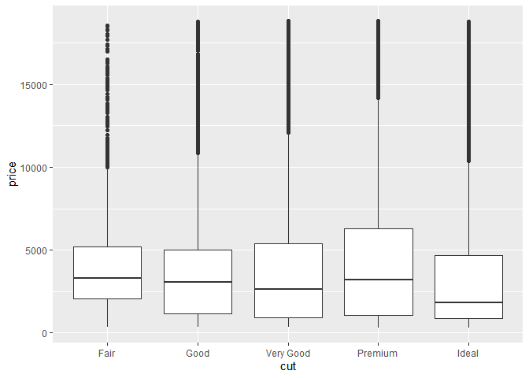

```r
ggplot(diamonds, aes(cut,price)) + geom_boxplot()
```

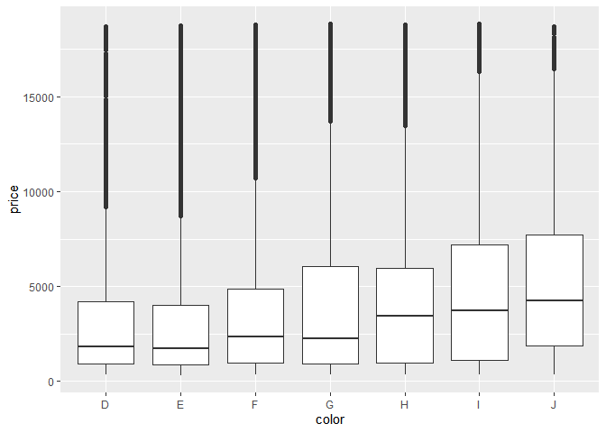

```r
ggplot(diamonds, aes(color, price)) + geom_boxplot()
```

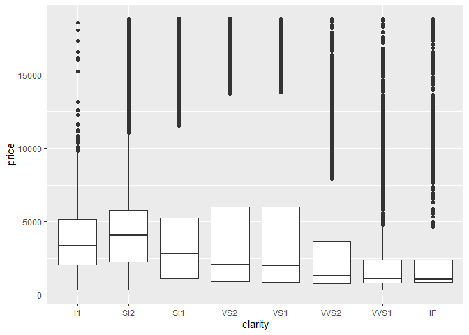

```r
ggplot(diamonds, aes(clarity, price)) + geom_boxplot()
```

In tutti e tre i grafici il prezzo sembra *diminuire* al migliorare della qualità: i diamanti con cut Fair, colore J e clarity I1 hanno prezzi mediani più alti di quelli con cut Ideal, colore D e clarity IF. È controintuitivo: ci aspetteremmo l’opposto. Il confronto però non tiene conto di altre variabili che potrebbero differire tra i gruppi, prima fra tutte il peso (`carat`).

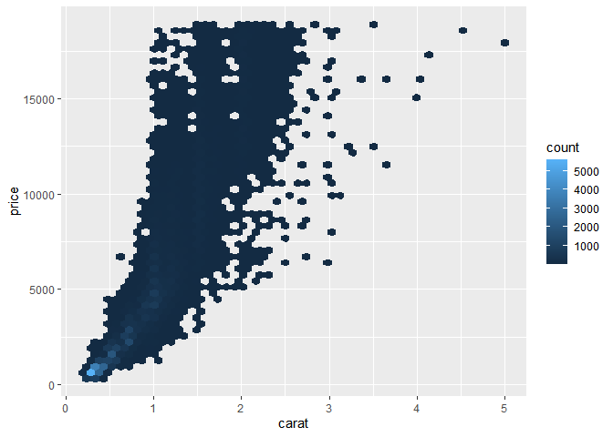

```r
ggplot(diamonds, aes(carat, price)) +
  geom_hex(bins=50)
```

Notiamo che il prezzo cresce fortemente con il carato, e la relazione non è lineare: il prezzo sale più che proporzionalmente al peso. Il carato è quindi un determinante fondamentale del prezzo.

Ora analizziamo le tre specifiche di qualità (taglio, colore e chiarezza) in relazione al carato del diamante:

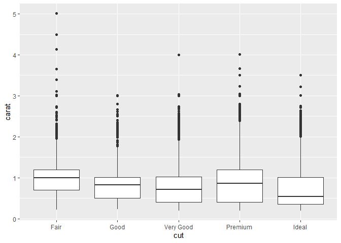

```r
ggplot(diamonds, aes(cut, carat)) + geom_boxplot()
```

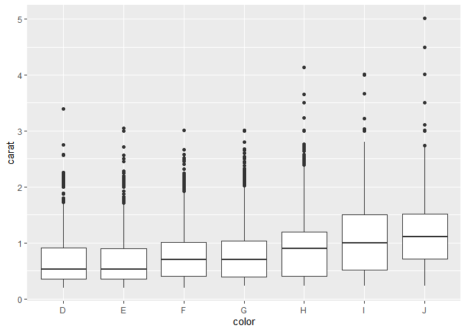

```r
ggplot(diamonds, aes(color, carat)) + geom_boxplot()
```

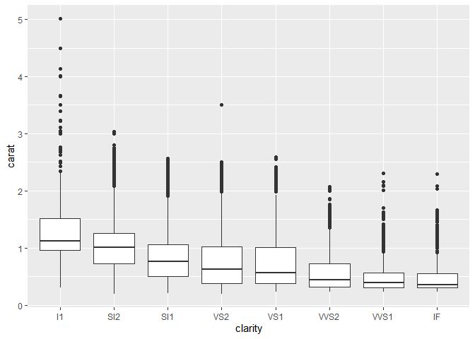

```r
ggplot(diamonds, aes(clarity, carat)) + geom_boxplot()
```

I diamanti di qualità peggiore sono mediamente più pesanti: il carato mediano è più alto per cut Fair, colore J e clarity I1, e più basso per Ideal, D e IF. Questa è la chiave del paradosso: la qualità è associata negativamente al carato, e il carato è associato positivamente al prezzo. Il carato è quindi una variabile confondente.

### Modello: prezzo in funzione del carato

La relazione prezzo-carato non è lineare, ma lo diventa in scala logaritmica. Uso `log2` così che un incremento di 1 corrisponda a un raddoppio:

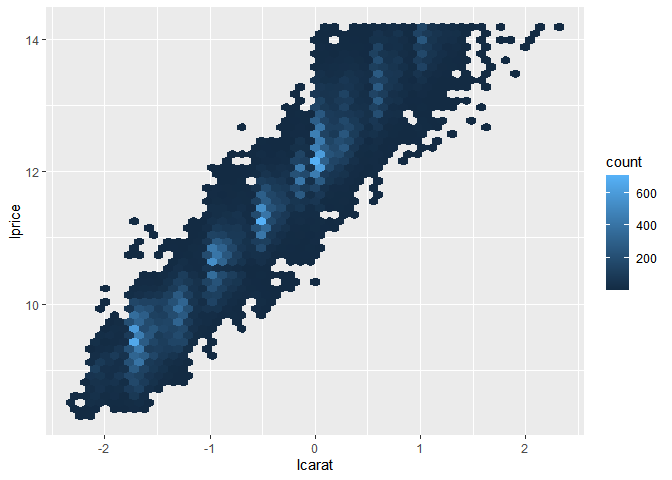

```r
diamonds2 <- diamonds |>
  mutate(lprice = log2(price),
         lcarat = log2(carat))

ggplot(diamonds2, aes(lcarat, lprice)) + geom_hex(bins = 50)
```

In scala log-log la nuvola di punti diventa approssimativamente lineare, quindi un modello lineare su `log2(price) ~ log2(carat)` è appropriato. Una relazione lineare in scala log corrisponde a una legge di potenza sulla scala originale.

```r
mod_carat <- lm(lprice ~ lcarat, data = diamonds2)

summary(mod_carat)
```

```
##
## Call:
## lm(formula = lprice ~ lcarat, data = diamonds2)
##
## Residuals:
##      Min       1Q   Median       3Q      Max
## -2.17606 -0.24456 -0.00853  0.24002  1.93023
##
## Coefficients:
##              Estimate Std. Error t value Pr(>|t|)
## (Intercept) 12.188841   0.001969  6190.9   <2e-16 ***
## lcarat       1.675817   0.001934   866.6   <2e-16 ***
## ---
## Signif. codes:  0 '***' 0.001 '**' 0.01 '*' 0.05 '.' 0.1 ' ' 1
##
## Residual standard error: 0.3789 on 53938 degrees of freedom
## Multiple R-squared:  0.933,  Adjusted R-squared:  0.933
## F-statistic: 7.51e+05 on 1 and 53938 DF,  p-value: < 2.2e-16
```

Vediamo come questo modello si adatta ai nostri dati:

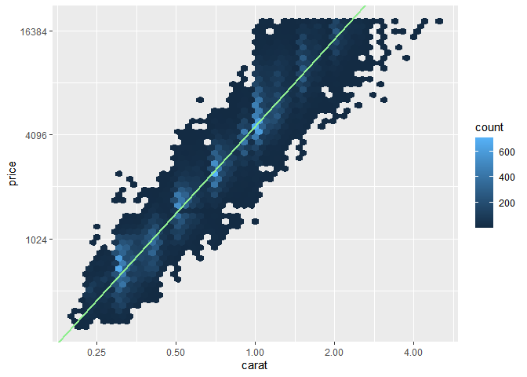

```r
a = mod_carat$coefficients[1]
b = mod_carat$coefficients[2]

ggplot(diamonds, aes(carat, price))+
  geom_hex(bins = 50)+
  scale_x_continuous(trans = "log2")+
  scale_y_continuous(trans = "log2")+
  geom_abline(intercept = a,
              slope = b,
              colour = "lightgreen",
              linewidth = 1)
```

Si osserva che la retta prevista dal modello segue bene l’andamento dei dati. Il modello cattura la componente di prezzo spiegata dal solo peso. Ciò che resta, cioè i residui che è il prezzo “a parità di carato”.

### Residui:

Ora verifichiamo come si comportano i residui del modello:

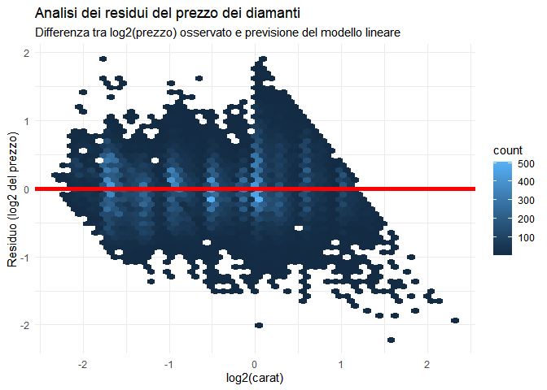

```r
diamonds2 <- diamonds2 |>
  add_residuals(mod_carat, "lresid")

ggplot(diamonds2, aes(x = lcarat, y = lresid)) +
  geom_hex(bins = 50) +
  geom_ref_line(h = 0, colour = "red") +
  labs(
    title = "Analisi dei residui del prezzo dei diamanti",
    subtitle = "Differenza tra log2(prezzo) osservato e previsione del modello lineare",
    x = "log2(carat)",
    y = "Residuo (log2 del prezzo)"
  ) +
  theme_minimal()
```

Si può notare che i residui sono centrati su zero e non dipendono più dal carato: il modello ha rimosso l’effetto del peso (un residuo di 1 in scala log2 vale un prezzo doppio).

Vediamo ora il comportamento dei residui in funzione della qualità del diamante:

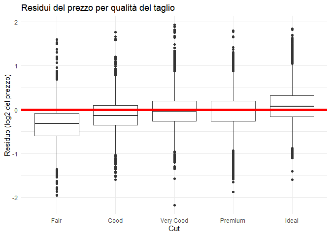

```r
ggplot(diamonds2, aes(x = cut, y = lresid)) +
  geom_boxplot() +
  geom_ref_line(h = 0, colour = "red") +
  labs(title = "Residui del prezzo per qualità del taglio",
       x = "Cut", y = "Residuo (log2 del prezzo)") +
  theme_minimal()
```

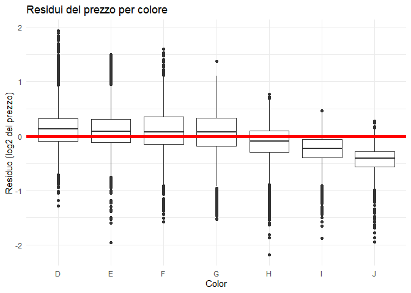

```r
ggplot(diamonds2, aes(x = color, y = lresid)) +
  geom_boxplot() +
  geom_ref_line(h = 0, colour = "red") +
  labs(title = "Residui del prezzo per colore",
       x = "Color", y = "Residuo (log2 del prezzo)") +
  theme_minimal()
```

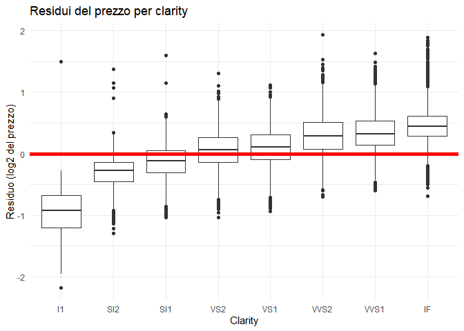

```r
ggplot(diamonds2, aes(x = clarity, y = lresid)) +
  geom_boxplot() +
  geom_ref_line(h = 0, colour = "red") +
  labs(title = "Residui del prezzo per clarity",
       x = "Clarity", y = "Residuo (log2 del prezzo)") +
  theme_minimal()
```

Possiamo notare che a parità di carato la relazione si ribalta: cut, colore e clarity migliori hanno residui più alti, cioè prezzi più alti,dunque confermiamo che il paradosso era dovuto al carato.

### Correlazioni:

Vediamo che risultati otteniamo dai coefficienti di correlazione:

```r
#coefficiente di pearson
cor_raw = cor(diamonds2$carat, diamonds2$price)
cor_spear = cor(diamonds2$carat, diamonds2$price, method = "spearman")
cor_log = cor(diamonds2$lcarat,diamonds2$lprice)
r2 = summary(mod_carat)$r.squared

df = data.frame(
  indice = c("Pearson (carat, price)", "Spearman (carat, price)", "Pearson(log carat, log price)", "R^2 modello log-log"),
  valore = round(c(cor_raw, cor_spear, cor_log, r2), 3)
)

df
```

```
##                          indice valore
## 1        Pearson (carat, price)  0.922
## 2       Spearman (carat, price)  0.963
## 3 Pearson(log carat, log price)  0.966
## 4           R^2 modello log-log  0.933
```

Su questi valori possiamo fare delle osservazioni:

- Sulla scala originale Il coefficiente di Spearman è più alto di quello di Pearson perchè la relazione è molto forte ma non lineare in quanto Spearman misura la monotonia (al crescere del carato il prezzo cresce sempre) mentre pearson misura solo la linearità, che qui è imperfetta.
- Il coeffiente di Pearson sulla scala logaritmica è maggiore della stessa statistica sulla scala originale, confermando quindi che la trasformazione logaritmica che abbiamo applicato linearizza la relazione, come abbiamo visto nel grafico.
- Il coefficiente $R^2$ ci indica che circa il 93% della variabilità del log-prezzo è spiegata dal solo carato.

### Conclusioni:

Inizialmente, considerando una variabile alla volta, la qualità peggiore sembra associata a un prezzo più alto, il che sembra paradossale. Abbiamo scoperto che il carato è il principale determinante del prezzo ed è correlato negativamente con la qualità, perché i diamanti grandi tendono ad avere cut, colore e clarity peggiori. Il carato è quindi una variabile confondente. Infine modellando il prezzo in funzione del carato e osservando i residui, l’effetto della qualità ha il segno atteso: a parità delle altre caratteristiche, i diamanti di qualità migliore costano di più.